# MH Predictable Analysis - Household Financial Flows

jingyao

2025-12-08

## Import Data

```r
# Import Stata data file
data_path <- "C:/Users/jingy/Dropbox/VIP/09. Main study/09. Data/20. Generated/simon_analysis/30_merged_panel-hh_id-period.dta"

# Check if file exists
if (!file.exists(data_path)) {
  stop("Error: Data file not found at: ", data_path)
}

cat("Loading data from:", data_path, "\n")
data <- read_dta(data_path)
cat("Data loaded successfully!\n")
cat("Dimensions:", nrow(data), "rows x", ncol(data), "columns\n\n")
```

## Check Available Variables

```r
cat("=== CHECKING AVAILABLE VARIABLES IN DATASET ===\n\n")

# Print all variable names
cat("All variables in dataset:\n")
print(names(data))

cat("\n\n=== CHECKING KEY VARIABLES FOR ANALYSIS ===\n\n")

# Check for adult equivalent variables
ae_vars <- grep("_ae", names(data), value = TRUE)
cat("Adult Equivalent variables found:\n")
if (length(ae_vars) > 0) {
  print(ae_vars)
} else {
  cat("  None found - will need to calculate manually\n")
}

# Check for per capita variables
pc_vars <- grep("_pc", names(data), value = TRUE)
cat("\nPer Capita variables found:\n")
if (length(pc_vars) > 0) {
  print(pc_vars)
} else {
  cat("  None found\n")
}

# Check for key financial variables
cat("\nKey financial variables:\n")
key_vars <- c("total_income_99", "total_consumption_99", "food_consumption_total_99",
              "adult_equivalent", "hh_size", "num_children", "working_adults_corrected",
              "asset_net_99", "ls_sold_total_99", "ls_bought_total_99",
              "dg_sell_total_value_99", "dg_buy_total_value_99")
for (var in key_vars) {
  exists <- var %in% names(data)
  cat(sprintf("  %s: %s\n", var, ifelse(exists, "✓ Found", "✗ NOT FOUND")))
}

cat("\n")
```

## Filter and Prepare Data

```r
# Include both treatment (predictable == 1) and control (control == 1) groups
data_analysis <- data %>%
  mutate(
    # Create treatment group labels
    group_label = case_when(
      control == 1 ~ "Control",
      predictable == 1 & period == 0 ~ "Baseline",
      predictable == 1 & draw == "H" ~ "High Draw",
      predictable == 1 & draw == "L" ~ "Low Draw",
      TRUE ~ "Unknown"
    ),
    high_draw = ifelse(draw == "H", 1, 0),
    period_label = case_when(
      period == 0 ~ "Period 0 (Baseline)",
      TRUE ~ paste0("Period ", period)
    )
  )

cat("Dataset with treatment and control groups:\n")
cat("  Total observations:", nrow(data_analysis), "\n")
cat("  Unique households:", length(unique(data_analysis$hh_id)), "\n")
cat("  Periods included:", sort(unique(data_analysis$period)), "\n\n")

# Summary of observations by period and group
cat("Observations by period and group:\n")
data_analysis %>%
  count(period, group_label) %>%
  arrange(period, group_label) %>%
  print()

# Summary by treatment status
cat("\n\nSummary by treatment status:\n")
data_analysis %>%
  group_by(predictable, control) %>%
  summarise(n = n(), .groups = "drop") %>%
  print()
```

# VISUALIZATION: OUTCOMES BY PERIOD

## Mental Health Outcomes Over Time

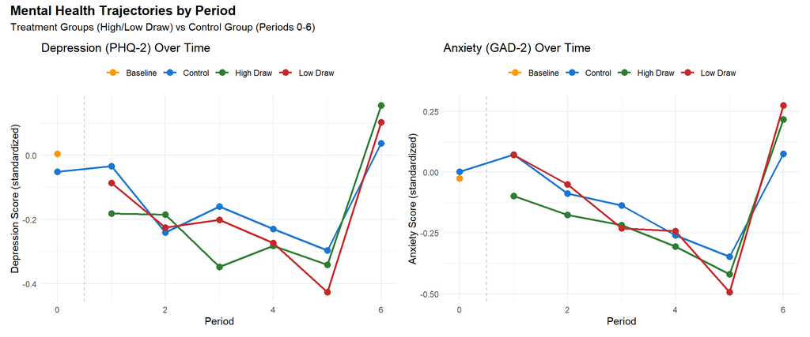

```r
# Mental health outcomes
mh_data <- data_analysis %>%
  group_by(period, group_label) %>%
  summarise(
    depression = mean(phq2_z, na.rm = TRUE),
    anxiety = mean(gad2_z, na.rm = TRUE),
    .groups = "drop"
  ) %>%
  filter(group_label != "Unknown")

p_depression <- ggplot(mh_data, aes(x = period, y = depression, color = group_label)) +
  geom_line(linewidth = 1) +
  geom_point(size = 3) +
  geom_vline(xintercept = 0.5, linetype = "dashed", color = "gray50", alpha = 0.5) +
  scale_color_manual(values = c("Baseline" = "#FF9800",
                                "High Draw" = "#2E7D32",
                                "Low Draw" = "#C62828",
                                "Control" = "#1976D2")) +
  labs(
    title = "Depression (PHQ-2) Over Time",
    x = "Period",
    y = "Depression Score (standardized)",
    color = NULL
  ) +
  theme_minimal() +
  theme(legend.position = "top")

p_anxiety <- ggplot(mh_data, aes(x = period, y = anxiety, color = group_label)) +
  geom_line(linewidth = 1) +
  geom_point(size = 3) +
  geom_vline(xintercept = 0.5, linetype = "dashed", color = "gray50", alpha = 0.5) +
  scale_color_manual(values = c("Baseline" = "#FF9800",
                                "High Draw" = "#2E7D32",
                                "Low Draw" = "#C62828",
                                "Control" = "#1976D2")) +
  labs(
    title = "Anxiety (GAD-2) Over Time",
    x = "Period",
    y = "Anxiety Score (standardized)",
    color = NULL
  ) +
  theme_minimal() +
  theme(legend.position = "top")

p_depression + p_anxiety +
  plot_annotation(
    title = "Mental Health Trajectories by Period",
    subtitle = "Treatment Groups (High/Low Draw) vs Control Group (Periods 0-6)",
    theme = theme(plot.title = element_text(face = "bold", size = 14))
  )
```

**Note:** Mental health is measured using standardized PHQ-2 (depression) and GAD-2 (anxiety) scales. Lower scores indicate better mental health. The control group (blue) received no cash transfers throughout the study. The baseline period (period 0, orange) shows pre-treatment outcomes for the treatment group before randomization into high or low draw schedules. Comparing treatment groups to control helps identify whether cash transfers improved mental health outcomes.

## Food Consumption Over Time

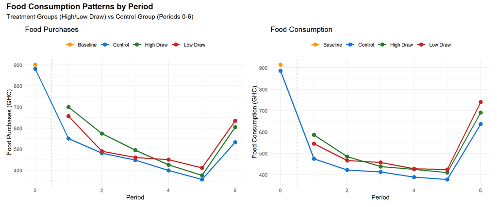

```r
food_data <- data_analysis %>%
  group_by(period, group_label) %>%
  summarise(
    food_purchases = mean(food_purchase_total_99, na.rm = TRUE),
    food_consumption = mean(food_consumption_total_99, na.rm = TRUE),
    .groups = "drop"
  ) %>%
  filter(group_label != "Unknown")

p_purchases <- ggplot(food_data, aes(x = period, y = food_purchases, color = group_label)) +
  geom_line(linewidth = 1) +
  geom_point(size = 3) +
  geom_vline(xintercept = 0.5, linetype = "dashed", color = "gray50", alpha = 0.5) +
  scale_color_manual(values = c("Baseline" = "#FF9800",
                                "High Draw" = "#2E7D32",
                                "Low Draw" = "#C62828",
                                "Control" = "#1976D2")) +
  labs(
    title = "Food Purchases",
    x = "Period",
    y = "Food Purchases (GHC)",
    color = NULL
  ) +
  theme_minimal() +
  theme(legend.position = "top")

p_consumption <- ggplot(food_data, aes(x = period, y = food_consumption, color = group_label)) +
  geom_line(linewidth = 1) +
  geom_point(size = 3) +
  geom_vline(xintercept = 0.5, linetype = "dashed", color = "gray50", alpha = 0.5) +
  scale_color_manual(values = c("Baseline" = "#FF9800",
                                "High Draw" = "#2E7D32",
                                "Low Draw" = "#C62828",
                                "Control" = "#1976D2")) +
  labs(
    title = "Food Consumption",
    x = "Period",
    y = "Food Consumption (GHC)",
    color = NULL
  ) +
  theme_minimal() +
  theme(legend.position = "top")

p_purchases + p_consumption +
  plot_annotation(
    title = "Food Consumption Patterns by Period",
    subtitle = "Treatment Groups (High/Low Draw) vs Control Group (Periods 0-6)",
    theme = theme(plot.title = element_text(face = "bold", size = 14))
  )
```

## Income with vs. without Study Payments

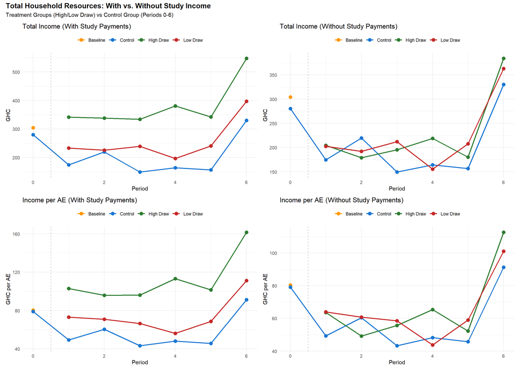

```r
income_comp_data <- data_analysis %>%
  group_by(period, group_label) %>%
  summarise(
    income_w_study = mean(total_income_99_w_study, na.rm = TRUE),
    income_wo_study = mean(total_income_99, na.rm = TRUE),
    income_w_study_ae = mean(total_income_99_w_study_ae, na.rm = TRUE),
    income_wo_study_ae = mean(total_income_99_ae, na.rm = TRUE),
    .groups = "drop"
  ) %>%
  filter(group_label != "Unknown")

p_inc_w <- ggplot(income_comp_data, aes(x = period, y = income_w_study, color = group_label)) +
  geom_line(linewidth = 1) +
  geom_point(size = 3) +
  geom_vline(xintercept = 0.5, linetype = "dashed", color = "gray50", alpha = 0.5) +
  scale_color_manual(values = c("Baseline" = "#FF9800", "High Draw" = "#2E7D32", "Low Draw" = "#C62828", "Control" = "#1976D2")) +
  labs(title = "Total Income (With Study Payments)", x = "Period", y = "GHC", color = NULL) +
  theme_minimal() +
  theme(legend.position = "top")

p_inc_wo <- ggplot(income_comp_data, aes(x = period, y = income_wo_study, color = group_label)) +
  geom_line(linewidth = 1) +
  geom_point(size = 3) +
  geom_vline(xintercept = 0.5, linetype = "dashed", color = "gray50", alpha = 0.5) +
  scale_color_manual(values = c("Baseline" = "#FF9800", "High Draw" = "#2E7D32", "Low Draw" = "#C62828", "Control" = "#1976D2")) +
  labs(title = "Total Income (Without Study Payments)", x = "Period", y = "GHC", color = NULL) +
  theme_minimal() +
  theme(legend.position = "top")

p_inc_w_ae <- ggplot(income_comp_data, aes(x = period, y = income_w_study_ae, color = group_label)) +
  geom_line(linewidth = 1) +
  geom_point(size = 3) +
  geom_vline(xintercept = 0.5, linetype = "dashed", color = "gray50", alpha = 0.5) +
  scale_color_manual(values = c("Baseline" = "#FF9800", "High Draw" = "#2E7D32", "Low Draw" = "#C62828", "Control" = "#1976D2")) +
  labs(title = "Income per AE (With Study Payments)", x = "Period", y = "GHC per AE", color = NULL) +
  theme_minimal() +
  theme(legend.position = "top")

p_inc_wo_ae <- ggplot(income_comp_data, aes(x = period, y = income_wo_study_ae, color = group_label)) +
  geom_line(linewidth = 1) +
  geom_point(size = 3) +
  geom_vline(xintercept = 0.5, linetype = "dashed", color = "gray50", alpha = 0.5) +
  scale_color_manual(values = c("Baseline" = "#FF9800", "High Draw" = "#2E7D32", "Low Draw" = "#C62828", "Control" = "#1976D2")) +
  labs(title = "Income per AE (Without Study Payments)", x = "Period", y = "GHC per AE", color = NULL) +
  theme_minimal() +
  theme(legend.position = "top")

(p_inc_w + p_inc_wo) / (p_inc_w_ae + p_inc_wo_ae) +
  plot_annotation(
    title = "Total Household Resources: With vs. Without Study Income",
    subtitle = "Treatment Groups (High/Low Draw) vs Control Group (Periods 0-6)",
    theme = theme(plot.title = element_text(face = "bold", size = 14))
  )
```

**Note:** This comparison shows the total resources available to households including versus excluding the experimental study payments. “With Study Payments” (`total_income_99_w_study`) includes all income sources: study income from the experiment, labor income, agricultural income, and other sources. “Without Study Payments” (`total_income_99`) excludes the experimental transfers, showing only naturally occurring household income. The difference between these measures reveals the direct income boost from the cash transfer experiment and helps identify whether households use study income to substitute for (reduce) other income-generating activities, or whether it represents pure additional resources. The control group provides a counterfactual showing what income would have been without any experimental intervention.

## Income Source Decomposition Over Time

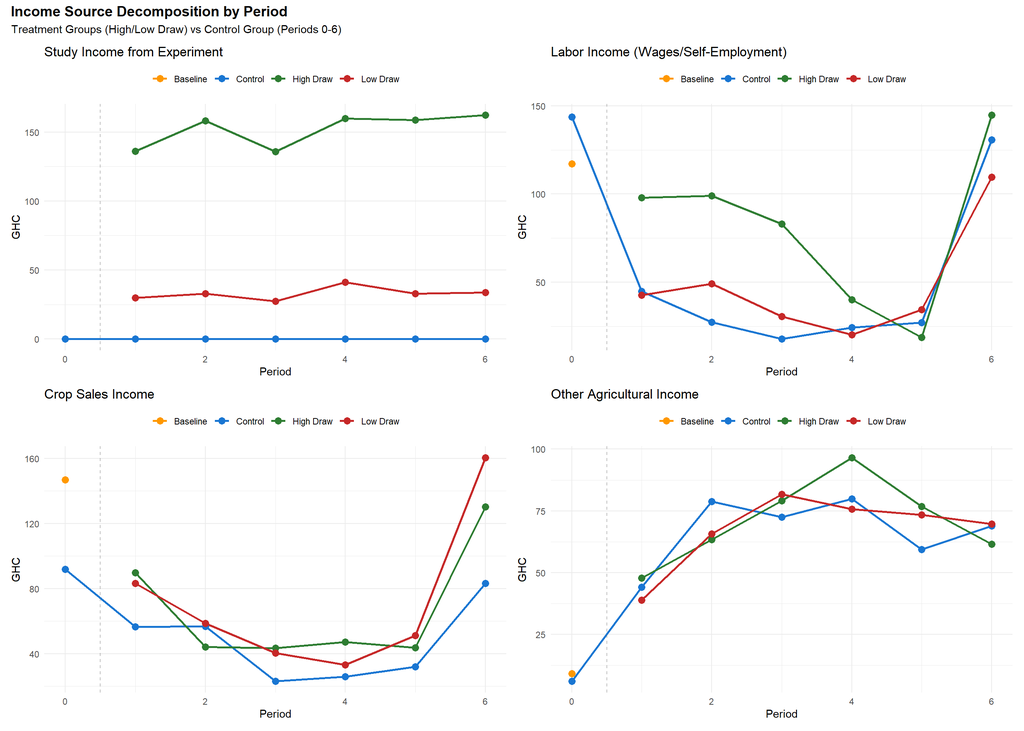

```r
income_decomp_data <- data_analysis %>%
  group_by(period, group_label) %>%
  summarise(
    study_income = mean(pass_bags * 12, na.rm = TRUE),
    labor_income = mean(money_work_99, na.rm = TRUE),
    crop_income = mean(crop_sold_price_total_99, na.rm = TRUE),
    other_ag_income = mean(otherag_sale_value_99, na.rm = TRUE),
    .groups = "drop"
  ) %>%
  filter(group_label != "Unknown")

p_study_inc <- ggplot(income_decomp_data, aes(x = period, y = study_income, color = group_label)) +
  geom_line(linewidth = 1) +
  geom_point(size = 3) +
  geom_vline(xintercept = 0.5, linetype = "dashed", color = "gray50", alpha = 0.5) +
  scale_color_manual(values = c("Baseline" = "#FF9800", "High Draw" = "#2E7D32", "Low Draw" = "#C62828", "Control" = "#1976D2")) +
  labs(title = "Study Income from Experiment", x = "Period", y = "GHC", color = NULL) +
  theme_minimal() +
  theme(legend.position = "top")

p_labor_inc <- ggplot(income_decomp_data, aes(x = period, y = labor_income, color = group_label)) +
  geom_line(linewidth = 1) +
  geom_point(size = 3) +
  geom_vline(xintercept = 0.5, linetype = "dashed", color = "gray50", alpha = 0.5) +
  scale_color_manual(values = c("Baseline" = "#FF9800", "High Draw" = "#2E7D32", "Low Draw" = "#C62828", "Control" = "#1976D2")) +
  labs(title = "Labor Income (Wages/Self-Employment)", x = "Period", y = "GHC", color = NULL) +
  theme_minimal() +
  theme(legend.position = "top")

p_crop_inc <- ggplot(income_decomp_data, aes(x = period, y = crop_income, color = group_label)) +
  geom_line(linewidth = 1) +
  geom_point(size = 3) +
  geom_vline(xintercept = 0.5, linetype = "dashed", color = "gray50", alpha = 0.5) +
  scale_color_manual(values = c("Baseline" = "#FF9800", "High Draw" = "#2E7D32", "Low Draw" = "#C62828", "Control" = "#1976D2")) +
  labs(title = "Crop Sales Income", x = "Period", y = "GHC", color = NULL) +
  theme_minimal() +
  theme(legend.position = "top")

p_otherag_inc <- ggplot(income_decomp_data, aes(x = period, y = other_ag_income, color = group_label)) +
  geom_line(linewidth = 1) +
  geom_point(size = 3) +
  geom_vline(xintercept = 0.5, linetype = "dashed", color = "gray50", alpha = 0.5) +
  scale_color_manual(values = c("Baseline" = "#FF9800", "High Draw" = "#2E7D32", "Low Draw" = "#C62828", "Control" = "#1976D2")) +
  labs(title = "Other Agricultural Income", x = "Period", y = "GHC", color = NULL) +
  theme_minimal() +
  theme(legend.position = "top")

(p_study_inc + p_labor_inc) / (p_crop_inc + p_otherag_inc) +
  plot_annotation(
    title = "Income Source Decomposition by Period",
    subtitle = "Treatment Groups (High/Low Draw) vs Control Group (Periods 0-6)",
    theme = theme(plot.title = element_text(face = "bold", size = 14))
  )
```

**Note:** This decomposition breaks down total household income into its major components. Study income is the experimental cash transfer (pass_bags × 12 GHC). Labor income includes wages from employment and self-employment activities. Crop sales income captures revenue from selling agricultural crops. Other agricultural income includes sales from livestock, poultry, eggs, milk, and other farm products not captured in crop sales. Comparing these income streams reveals how households’ economic activities and income portfolios evolve in response to the experimental transfers, including potential substitution effects (e.g., reducing labor supply when receiving transfers) or complementarity effects (e.g., using transfers to invest in agricultural production).

## Expenditures Over Time

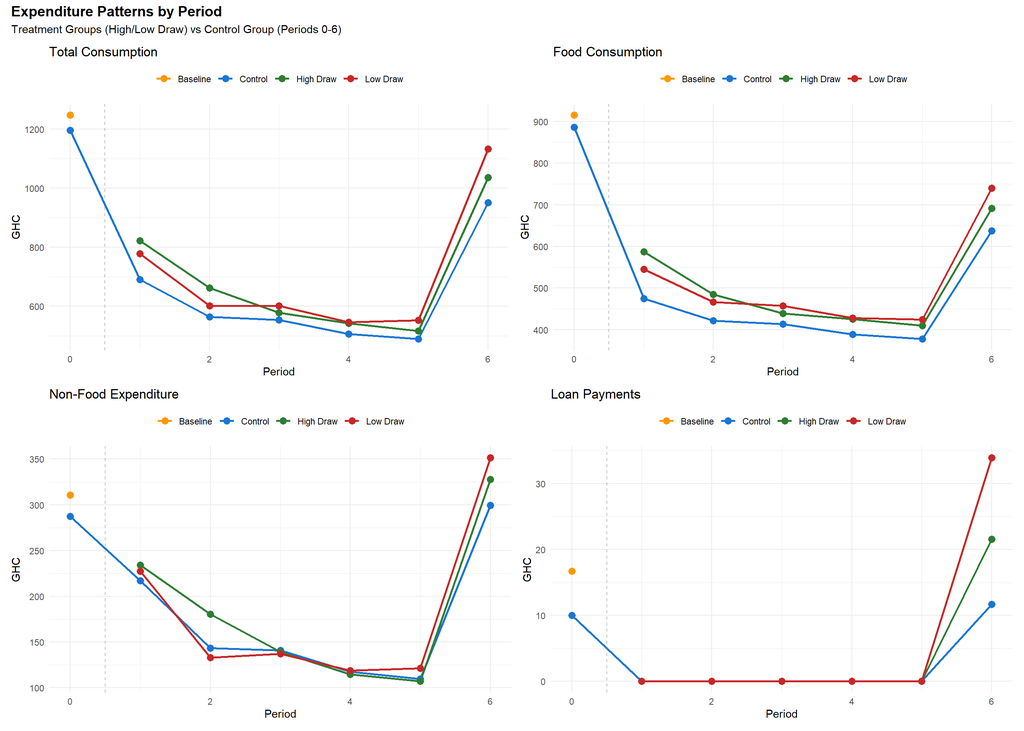

```r
expenditure_data <- data_analysis %>%
  group_by(period, group_label) %>%
  summarise(
    total_consumption = mean(total_consumption_99, na.rm = TRUE),
    food_consumption = mean(food_consumption_total_99, na.rm = TRUE),
    nonfood_expenditure = mean(expenditure_total_nonfood_99, na.rm = TRUE),
    loan_payments = mean(loan_total_payment, na.rm = TRUE),
    .groups = "drop"
  ) %>%
  filter(group_label != "Unknown")

p_total_cons <- ggplot(expenditure_data, aes(x = period, y = total_consumption, color = group_label)) +
  geom_line(linewidth = 1) +
  geom_point(size = 3) +
  geom_vline(xintercept = 0.5, linetype = "dashed", color = "gray50", alpha = 0.5) +
  scale_color_manual(values = c("Baseline" = "#FF9800", "High Draw" = "#2E7D32", "Low Draw" = "#C62828", "Control" = "#1976D2")) +
  labs(title = "Total Consumption", x = "Period", y = "GHC", color = NULL) +
  theme_minimal() +
  theme(legend.position = "top")

p_food_cons <- ggplot(expenditure_data, aes(x = period, y = food_consumption, color = group_label)) +
  geom_line(linewidth = 1) +
  geom_point(size = 3) +
  geom_vline(xintercept = 0.5, linetype = "dashed", color = "gray50", alpha = 0.5) +
  scale_color_manual(values = c("Baseline" = "#FF9800", "High Draw" = "#2E7D32", "Low Draw" = "#C62828", "Control" = "#1976D2")) +
  labs(title = "Food Consumption", x = "Period", y = "GHC", color = NULL) +
  theme_minimal() +
  theme(legend.position = "top")

p_nonfood <- ggplot(expenditure_data, aes(x = period, y = nonfood_expenditure, color = group_label)) +
  geom_line(linewidth = 1) +
  geom_point(size = 3) +
  geom_vline(xintercept = 0.5, linetype = "dashed", color = "gray50", alpha = 0.5) +
  scale_color_manual(values = c("Baseline" = "#FF9800", "High Draw" = "#2E7D32", "Low Draw" = "#C62828", "Control" = "#1976D2")) +
  labs(title = "Non-Food Expenditure", x = "Period", y = "GHC", color = NULL) +
  theme_minimal() +
  theme(legend.position = "top")

p_loan_pay <- ggplot(expenditure_data, aes(x = period, y = loan_payments, color = group_label)) +
  geom_line(linewidth = 1) +
  geom_point(size = 3) +
  geom_vline(xintercept = 0.5, linetype = "dashed", color = "gray50", alpha = 0.5) +
  scale_color_manual(values = c("Baseline" = "#FF9800", "High Draw" = "#2E7D32", "Low Draw" = "#C62828", "Control" = "#1976D2")) +
  labs(title = "Loan Payments", x = "Period", y = "GHC", color = NULL) +
  theme_minimal() +
  theme(legend.position = "top")

(p_total_cons + p_food_cons) / (p_nonfood + p_loan_pay) +
  plot_annotation(
    title = "Expenditure Patterns by Period",
    subtitle = "Treatment Groups (High/Low Draw) vs Control Group (Periods 0-6)",
    theme = theme(plot.title = element_text(face = "bold", size = 14))
  )
```

**Note:** Expenditure patterns show how households allocate resources across different categories. Total consumption includes food and non-food expenditures plus the value of home production. Food consumption reflects household dietary quality and food security. Non-food expenditures include clothing, utilities, transportation, education, and other non-food items. Loan payments represent debt servicing obligations. Comparing treatment to control groups reveals whether cash transfers increase consumption (potentially improving living standards) or are saved/invested.

## Financial Position Over Time

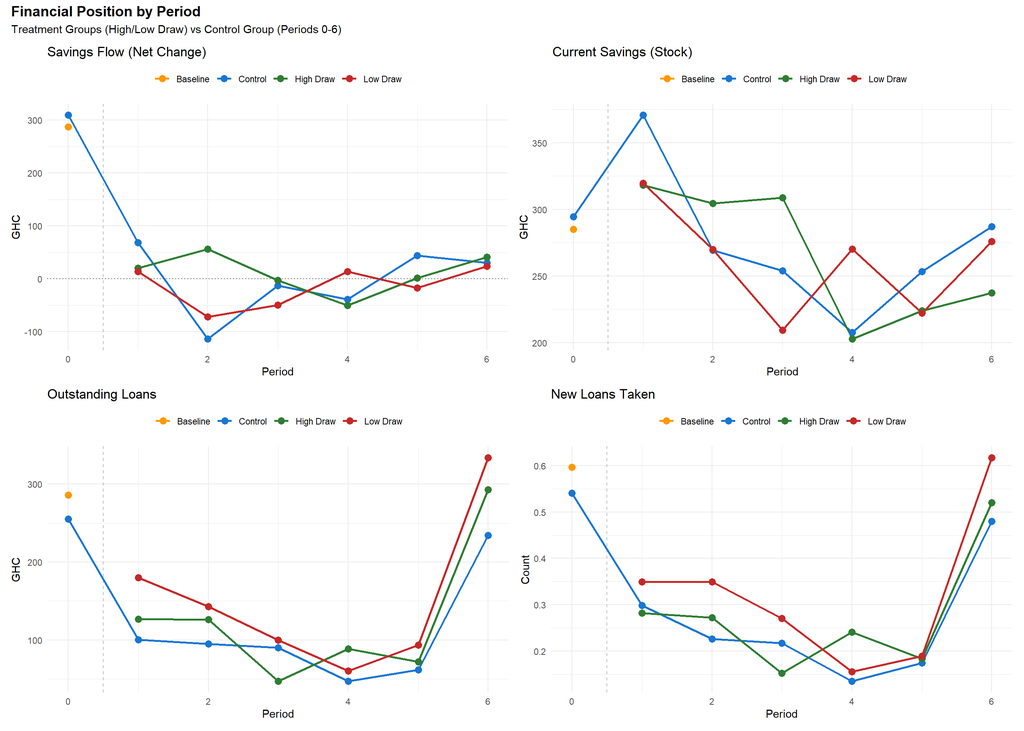

```r
financial_position_data <- data_analysis %>%
  group_by(period, group_label) %>%
  summarise(
    savings_flow = mean(savings_flow_99, na.rm = TRUE),
    current_savings = mean(current_savings_99, na.rm = TRUE),
    outstanding_loans = mean(loan_total_outstanding_99, na.rm = TRUE),
    loans_taken = mean(loans_taken, na.rm = TRUE),
    .groups = "drop"
  ) %>%
  filter(group_label != "Unknown")

p_sav_flow <- ggplot(financial_position_data, aes(x = period, y = savings_flow, color = group_label)) +
  geom_line(linewidth = 1) +
  geom_point(size = 3) +
  geom_vline(xintercept = 0.5, linetype = "dashed", color = "gray50", alpha = 0.5) +
  geom_hline(yintercept = 0, linetype = "dotted", color = "gray30") +
  scale_color_manual(values = c("Baseline" = "#FF9800", "High Draw" = "#2E7D32", "Low Draw" = "#C62828", "Control" = "#1976D2")) +
  labs(title = "Savings Flow (Net Change)", x = "Period", y = "GHC", color = NULL) +
  theme_minimal() +
  theme(legend.position = "top")

p_curr_sav <- ggplot(financial_position_data, aes(x = period, y = current_savings, color = group_label)) +
  geom_line(linewidth = 1) +
  geom_point(size = 3) +
  geom_vline(xintercept = 0.5, linetype = "dashed", color = "gray50", alpha = 0.5) +
  scale_color_manual(values = c("Baseline" = "#FF9800", "High Draw" = "#2E7D32", "Low Draw" = "#C62828", "Control" = "#1976D2")) +
  labs(title = "Current Savings (Stock)", x = "Period", y = "GHC", color = NULL) +
  theme_minimal() +
  theme(legend.position = "top")

p_out_loans <- ggplot(financial_position_data, aes(x = period, y = outstanding_loans, color = group_label)) +
  geom_line(linewidth = 1) +
  geom_point(size = 3) +
  geom_vline(xintercept = 0.5, linetype = "dashed", color = "gray50", alpha = 0.5) +
  scale_color_manual(values = c("Baseline" = "#FF9800", "High Draw" = "#2E7D32", "Low Draw" = "#C62828", "Control" = "#1976D2")) +
  labs(title = "Outstanding Loans", x = "Period", y = "GHC", color = NULL) +
  theme_minimal() +
  theme(legend.position = "top")

p_new_loans <- ggplot(financial_position_data, aes(x = period, y = loans_taken, color = group_label)) +
  geom_line(linewidth = 1) +
  geom_point(size = 3) +
  geom_vline(xintercept = 0.5, linetype = "dashed", color = "gray50", alpha = 0.5) +
  scale_color_manual(values = c("Baseline" = "#FF9800", "High Draw" = "#2E7D32", "Low Draw" = "#C62828", "Control" = "#1976D2")) +
  labs(title = "New Loans Taken", x = "Period", y = "Count", color = NULL) +
  theme_minimal() +
  theme(legend.position = "top")

(p_sav_flow + p_curr_sav) / (p_out_loans + p_new_loans) +
  plot_annotation(
    title = "Financial Position by Period",
    subtitle = "Treatment Groups (High/Low Draw) vs Control Group (Periods 0-6)",
    theme = theme(plot.title = element_text(face = "bold", size = 14))
  )
```

**Note:** Financial position tracks household savings and debt dynamics. Savings flow measures the net change in savings during a period (positive = accumulating, negative = drawing down savings). Current savings shows the stock of liquid savings held at the time of the survey. Outstanding loans captures total debt owed across all sources (formal lenders, informal lenders, family/friends). New loans taken counts the number of loans initiated in the period. Positive savings flow and declining debt indicate improving financial security, while the opposite pattern may signal financial stress or strategic use of credit. Comparing to control groups reveals whether cash transfers improve household financial resilience.

## Cash Flows Over Time

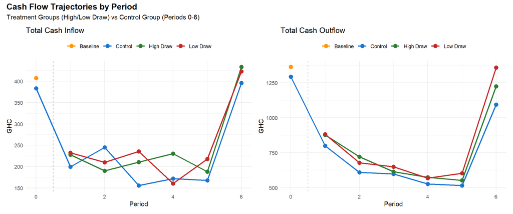

```r
cashflow_data <- data_analysis %>%
  group_by(period, group_label) %>%
  summarise(
    cash_inflow = mean(cash_inflow_99, na.rm = TRUE),
    cash_outflow = mean(cash_outflow_99, na.rm = TRUE),
    .groups = "drop"
  ) %>%
  filter(group_label != "Unknown")

p_inflow <- ggplot(cashflow_data, aes(x = period, y = cash_inflow, color = group_label)) +
  geom_line(linewidth = 1) +
  geom_point(size = 3) +
  geom_vline(xintercept = 0.5, linetype = "dashed", color = "gray50", alpha = 0.5) +
  scale_color_manual(values = c("Baseline" = "#FF9800", "High Draw" = "#2E7D32", "Low Draw" = "#C62828", "Control" = "#1976D2")) +
  labs(title = "Total Cash Inflow", x = "Period", y = "GHC", color = NULL) +
  theme_minimal() +
  theme(legend.position = "top")

p_outflow <- ggplot(cashflow_data, aes(x = period, y = cash_outflow, color = group_label)) +
  geom_line(linewidth = 1) +
  geom_point(size = 3) +
  geom_vline(xintercept = 0.5, linetype = "dashed", color = "gray50", alpha = 0.5) +
  scale_color_manual(values = c("Baseline" = "#FF9800", "High Draw" = "#2E7D32", "Low Draw" = "#C62828", "Control" = "#1976D2")) +
  labs(title = "Total Cash Outflow", x = "Period", y = "GHC", color = NULL) +
  theme_minimal() +
  theme(legend.position = "top")

p_inflow + p_outflow +
  plot_annotation(
    title = "Cash Flow Trajectories by Period",
    subtitle = "Treatment Groups (High/Low Draw) vs Control Group (Periods 0-6)",
    theme = theme(plot.title = element_text(face = "bold", size = 14))
  )
```

## Per Adult Equivalent Outcomes Over Time

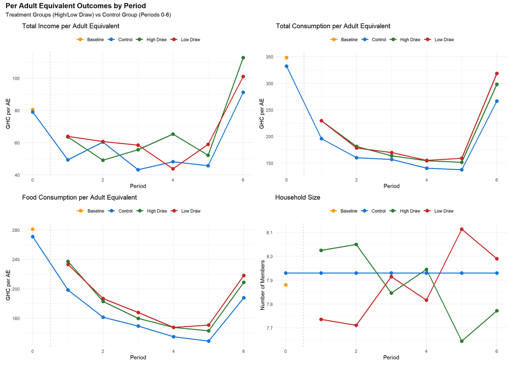

```r
per_ae_data <- data_analysis %>%
  group_by(period, group_label) %>%
  summarise(
    income_ae = mean(total_income_99_ae, na.rm = TRUE),
    consumption_ae = mean(total_consumption_99_ae, na.rm = TRUE),
    food_consumption_ae = mean(food_consumption_99_ae, na.rm = TRUE),
    hh_size = mean(hh_size, na.rm = TRUE),
    .groups = "drop"
  ) %>%
  filter(group_label != "Unknown")

p_income_ae <- ggplot(per_ae_data, aes(x = period, y = income_ae, color = group_label)) +
  geom_line(linewidth = 1) +
  geom_point(size = 3) +
  geom_vline(xintercept = 0.5, linetype = "dashed", color = "gray50", alpha = 0.5) +
  scale_color_manual(values = c("Baseline" = "#FF9800", "High Draw" = "#2E7D32", "Low Draw" = "#C62828", "Control" = "#1976D2")) +
  labs(title = "Total Income per Adult Equivalent", x = "Period", y = "GHC per AE", color = NULL) +
  theme_minimal() +
  theme(legend.position = "top")

p_cons_ae <- ggplot(per_ae_data, aes(x = period, y = consumption_ae, color = group_label)) +
  geom_line(linewidth = 1) +
  geom_point(size = 3) +
  geom_vline(xintercept = 0.5, linetype = "dashed", color = "gray50", alpha = 0.5) +
  scale_color_manual(values = c("Baseline" = "#FF9800", "High Draw" = "#2E7D32", "Low Draw" = "#C62828", "Control" = "#1976D2")) +
  labs(title = "Total Consumption per Adult Equivalent", x = "Period", y = "GHC per AE", color = NULL) +
  theme_minimal() +
  theme(legend.position = "top")

p_food_ae <- ggplot(per_ae_data, aes(x = period, y = food_consumption_ae, color = group_label)) +
  geom_line(linewidth = 1) +
  geom_point(size = 3) +
  geom_vline(xintercept = 0.5, linetype = "dashed", color = "gray50", alpha = 0.5) +
  scale_color_manual(values = c("Baseline" = "#FF9800", "High Draw" = "#2E7D32", "Low Draw" = "#C62828", "Control" = "#1976D2")) +
  labs(title = "Food Consumption per Adult Equivalent", x = "Period", y = "GHC per AE", color = NULL) +
  theme_minimal() +
  theme(legend.position = "top")

p_hhsize <- ggplot(per_ae_data, aes(x = period, y = hh_size, color = group_label)) +
  geom_line(linewidth = 1) +
  geom_point(size = 3) +
  geom_vline(xintercept = 0.5, linetype = "dashed", color = "gray50", alpha = 0.5) +
  scale_color_manual(values = c("Baseline" = "#FF9800", "High Draw" = "#2E7D32", "Low Draw" = "#C62828", "Control" = "#1976D2")) +
  labs(title = "Household Size", x = "Period", y = "Number of Members", color = NULL) +
  theme_minimal() +
  theme(legend.position = "top")

(p_income_ae + p_cons_ae) / (p_food_ae + p_hhsize) +
  plot_annotation(
    title = "Per Adult Equivalent Outcomes by Period",
    subtitle = "Treatment Groups (High/Low Draw) vs Control Group (Periods 0-6)",
    theme = theme(plot.title = element_text(face = "bold", size = 14))
  )
```

**Note:** Adult Equivalent (AE) measures adjust for household composition using standard equivalence scales. This controls for differences in household size and age composition, providing a more accurate comparison of living standards across households. For example, a household with 4 adults and 2 children has a higher AE than a household with 2 adults. Income and consumption per AE show the resources available to each “equivalent adult” in the household.

## Asset Dynamics Over Time

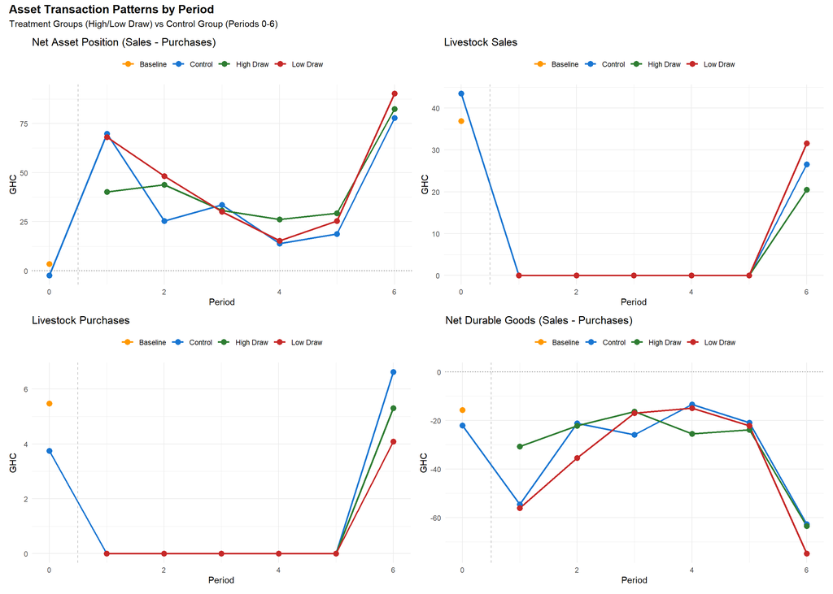

```r
asset_data <- data_analysis %>%
  group_by(period, group_label) %>%
  summarise(
    asset_net = mean(asset_net_99, na.rm = TRUE),
    livestock_sold = mean(ls_sold_total_99, na.rm = TRUE),
    livestock_bought = mean(ls_bought_total_99, na.rm = TRUE),
    durables_net = mean(dg_sell_total_value_99 - dg_buy_total_value_99, na.rm = TRUE),
    .groups = "drop"
  ) %>%
  filter(group_label != "Unknown")

p_asset_net <- ggplot(asset_data, aes(x = period, y = asset_net, color = group_label)) +
  geom_line(linewidth = 1) +
  geom_point(size = 3) +
  geom_vline(xintercept = 0.5, linetype = "dashed", color = "gray50", alpha = 0.5) +
  geom_hline(yintercept = 0, linetype = "dotted", color = "gray30") +
  scale_color_manual(values = c("Baseline" = "#FF9800", "High Draw" = "#2E7D32", "Low Draw" = "#C62828", "Control" = "#1976D2")) +
  labs(title = "Net Asset Position (Sales - Purchases)", x = "Period", y = "GHC", color = NULL) +
  theme_minimal() +
  theme(legend.position = "top")

p_ls_sold <- ggplot(asset_data, aes(x = period, y = livestock_sold, color = group_label)) +
  geom_line(linewidth = 1) +
  geom_point(size = 3) +
  geom_vline(xintercept = 0.5, linetype = "dashed", color = "gray50", alpha = 0.5) +
  scale_color_manual(values = c("Baseline" = "#FF9800", "High Draw" = "#2E7D32", "Low Draw" = "#C62828", "Control" = "#1976D2")) +
  labs(title = "Livestock Sales", x = "Period", y = "GHC", color = NULL) +
  theme_minimal() +
  theme(legend.position = "top")

p_ls_bought <- ggplot(asset_data, aes(x = period, y = livestock_bought, color = group_label)) +
  geom_line(linewidth = 1) +
  geom_point(size = 3) +
  geom_vline(xintercept = 0.5, linetype = "dashed", color = "gray50", alpha = 0.5) +
  scale_color_manual(values = c("Baseline" = "#FF9800", "High Draw" = "#2E7D32", "Low Draw" = "#C62828", "Control" = "#1976D2")) +
  labs(title = "Livestock Purchases", x = "Period", y = "GHC", color = NULL) +
  theme_minimal() +
  theme(legend.position = "top")

p_dg_net <- ggplot(asset_data, aes(x = period, y = durables_net, color = group_label)) +
  geom_line(linewidth = 1) +
  geom_point(size = 3) +
  geom_vline(xintercept = 0.5, linetype = "dashed", color = "gray50", alpha = 0.5) +
  geom_hline(yintercept = 0, linetype = "dotted", color = "gray30") +
  scale_color_manual(values = c("Baseline" = "#FF9800", "High Draw" = "#2E7D32", "Low Draw" = "#C62828", "Control" = "#1976D2")) +
  labs(title = "Net Durable Goods (Sales - Purchases)", x = "Period", y = "GHC", color = NULL) +
  theme_minimal() +
  theme(legend.position = "top")

(p_asset_net + p_ls_sold) / (p_ls_bought + p_dg_net) +
  plot_annotation(
    title = "Asset Transaction Patterns by Period",
    subtitle = "Treatment Groups (High/Low Draw) vs Control Group (Periods 0-6)",
    theme = theme(plot.title = element_text(face = "bold", size = 14))
  )
```

**Note:** Asset dynamics capture household investment and coping strategies. Positive net asset position (sales > purchases) may indicate distress selling or portfolio rebalancing, while negative values (purchases > sales) indicate asset accumulation. Livestock transactions are particularly important in rural contexts as they represent both savings vehicles and productive assets. Durable goods include items like furniture, appliances, and equipment. The dotted horizontal line at zero helps identify periods of net accumulation (below zero) versus net depletion (above zero).

## Labor Supply and Household Composition Over Time

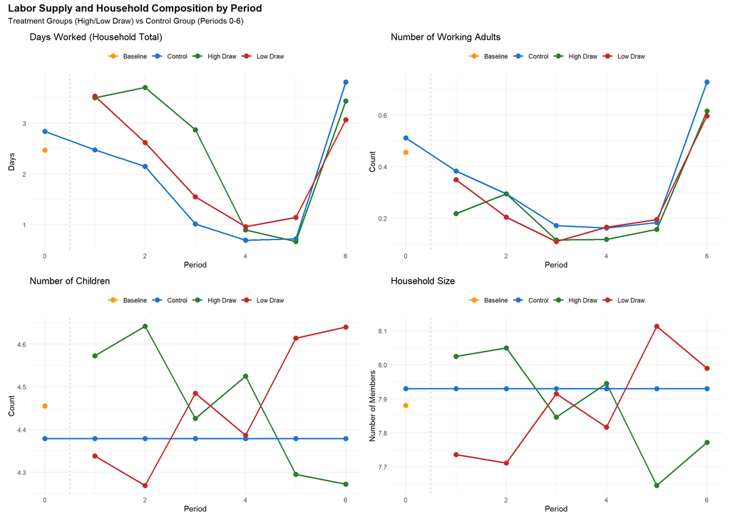

```r
labor_data <- data_analysis %>%
  group_by(period, group_label) %>%
  summarise(
    days_worked = mean(days_worked, na.rm = TRUE),
    working_adults = mean(working_adults_corrected, na.rm = TRUE),
    num_children = mean(num_children, na.rm = TRUE),
    hh_size = mean(hh_size, na.rm = TRUE),
    .groups = "drop"
  ) %>%
  filter(group_label != "Unknown")

p_days <- ggplot(labor_data, aes(x = period, y = days_worked, color = group_label)) +
  geom_line(linewidth = 1) +
  geom_point(size = 3) +
  geom_vline(xintercept = 0.5, linetype = "dashed", color = "gray50", alpha = 0.5) +
  scale_color_manual(values = c("Baseline" = "#FF9800", "High Draw" = "#2E7D32", "Low Draw" = "#C62828", "Control" = "#1976D2")) +
  labs(title = "Days Worked (Household Total)", x = "Period", y = "Days", color = NULL) +
  theme_minimal() +
  theme(legend.position = "top")

p_workers <- ggplot(labor_data, aes(x = period, y = working_adults, color = group_label)) +
  geom_line(linewidth = 1) +
  geom_point(size = 3) +
  geom_vline(xintercept = 0.5, linetype = "dashed", color = "gray50", alpha = 0.5) +
  scale_color_manual(values = c("Baseline" = "#FF9800", "High Draw" = "#2E7D32", "Low Draw" = "#C62828", "Control" = "#1976D2")) +
  labs(title = "Number of Working Adults", x = "Period", y = "Count", color = NULL) +
  theme_minimal() +
  theme(legend.position = "top")

p_children <- ggplot(labor_data, aes(x = period, y = num_children, color = group_label)) +
  geom_line(linewidth = 1) +
  geom_point(size = 3) +
  geom_vline(xintercept = 0.5, linetype = "dashed", color = "gray50", alpha = 0.5) +
  scale_color_manual(values = c("Baseline" = "#FF9800", "High Draw" = "#2E7D32", "Low Draw" = "#C62828", "Control" = "#1976D2")) +
  labs(title = "Number of Children", x = "Period", y = "Count", color = NULL) +
  theme_minimal() +
  theme(legend.position = "top")

p_hh_size2 <- ggplot(labor_data, aes(x = period, y = hh_size, color = group_label)) +
  geom_line(linewidth = 1) +
  geom_point(size = 3) +
  geom_vline(xintercept = 0.5, linetype = "dashed", color = "gray50", alpha = 0.5) +
  scale_color_manual(values = c("Baseline" = "#FF9800", "High Draw" = "#2E7D32", "Low Draw" = "#C62828", "Control" = "#1976D2")) +
  labs(title = "Household Size", x = "Period", y = "Number of Members", color = NULL) +
  theme_minimal() +
  theme(legend.position = "top")

(p_days + p_workers) / (p_children + p_hh_size2) +
  plot_annotation(
    title = "Labor Supply and Household Composition by Period",
    subtitle = "Treatment Groups (High/Low Draw) vs Control Group (Periods 0-6)",
    theme = theme(plot.title = element_text(face = "bold", size = 14))
  )
```

**Note:** Labor supply captures household work effort. Days worked is the total number of days any household member worked for pay during the recall period. Working adults counts the number of adults in the household who engaged in income-generating work. Changes in labor supply may reflect both income effects (working less when cash transfers are received) and substitution effects (reallocating time to other activities). Household composition variables (number of children, household size) may change over time due to births, deaths, or migration, affecting both labor supply and consumption needs. ```